# Final project

Natalia Misiaszek

2025-04-08

```r
dane= read.csv("/Users/misiaszekn/Downloads/pokedex.csv")
```

The data set we dispose is the list of pokemons with all their properties. In our general test we will be interested in comparing the means od two different samples- in our case two different types of pockemons. Let’s check which types of pockemons we actually have.

```r
library(dplyr)
dane %>%
  count(type, sort = TRUE) %>%
  slice(1:2)
```

```
##       type  n
## 1 {normal} 75
## 2  {water} 74
```

### Let’s set the speed of these two types of pockemons as samples, which we are going to compare.

Speed of {normal} and {water} pockemons are independent samples, because they belong to different types of pockemons.

#### Testing Assumptions

```r
speedofnormal= dane$speed[dane$type=="{normal}"]
speedofwater=dane$speed[dane$type=="{water}"]
```

#### 1) normality of samples

```r
shapiro.test(speedofwater)
```

```
##
##  Shapiro-Wilk normality test
##
## data:  speedofwater
## W = 0.98103, p-value = 0.3311
```

```r
shapiro.test(speedofnormal)
```

```
##
##  Shapiro-Wilk normality test
##
## data:  speedofnormal
## W = 0.97154, p-value = 0.08903
```

In both cases we get p-value>0.05 so definitelly should we not reject the zero hypothesis that our samples follow the normal distribution. In that case, to be sure about that, let’s do some plots and other tests.

```r
library(ggpubr)
```

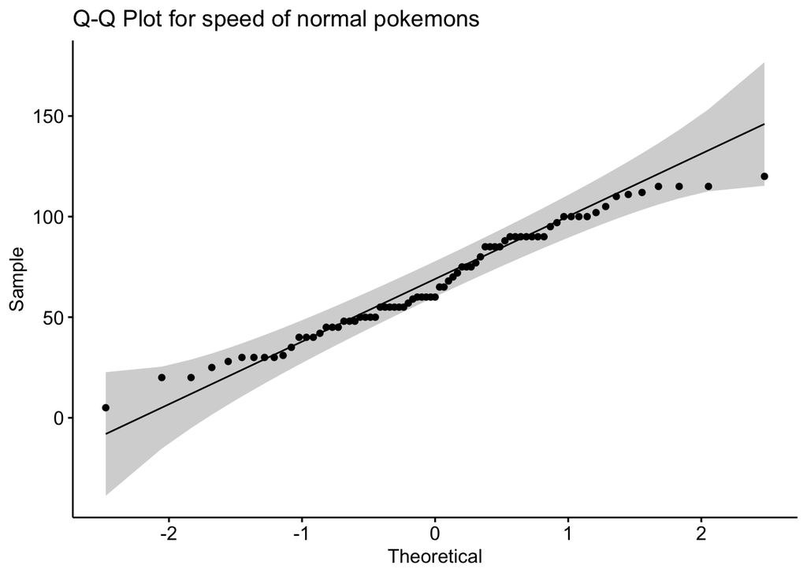

```r
ggqqplot(speedofnormal, conf.int= TRUE, conf.int.level=0.95, title="Q-Q Plot for speed of normal pokemons")
```

Sample quntiles seems to suit the normal distribution.

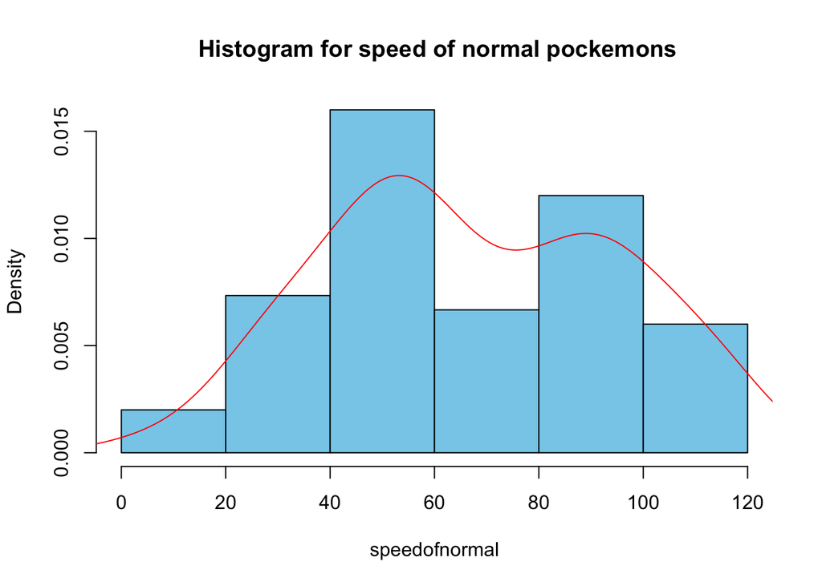

```r
hist(speedofnormal, probability= TRUE,col="skyblue", main=" Histogram for speed of normal pockemons")
lines(density(speedofnormal), col="red")
```

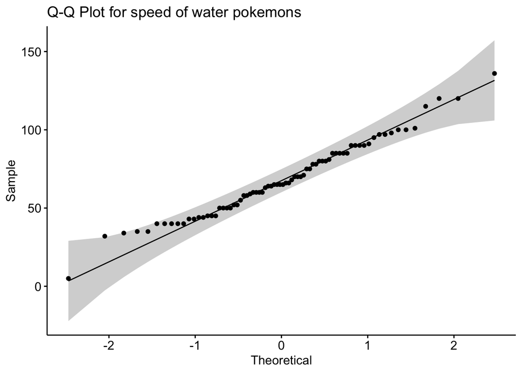

```r
library(ggpubr)
ggqqplot(speedofwater, conf.int= TRUE, conf.int.level=0.95, title="Q-Q Plot for speed of water pokemons")
```

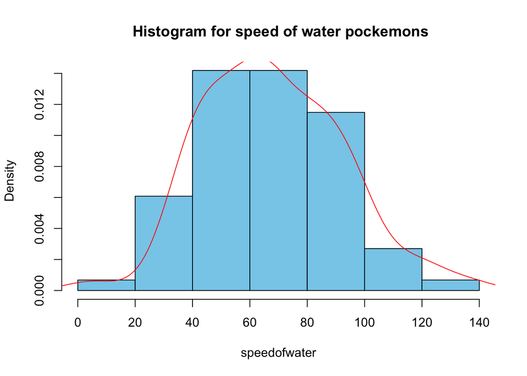

```r
hist(speedofwater, probability= TRUE,col="skyblue", main=" Histogram for speed of water pockemons")
lines(density(speedofwater), col="red")
```

```r
library(fitdistrplus)
```

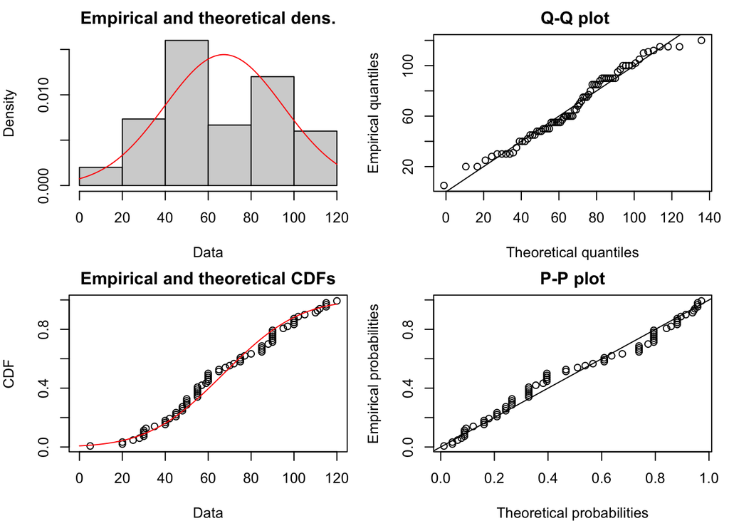

```r
fit_norm_normal <- fitdist(speedofnormal, "norm")
par(mar=c(4,4,2,1))
plot(fit_norm_normal)
```

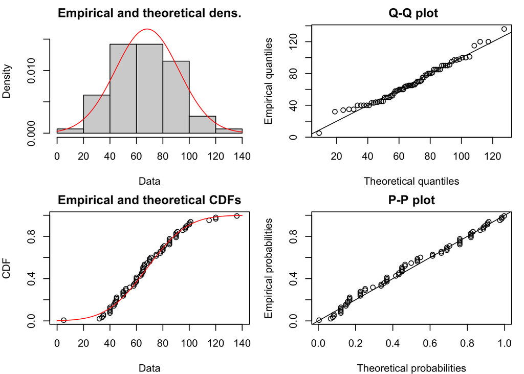

```r
fit_norm_water= fitdist(speedofwater, "norm")
par(mar=c(4,4,2,1))
plot(fit_norm_water)
```

As Shapiro- Wilk test and different plots indicates that samples follow normal distrbution, we accept that and check homogenity of variance.

#### 2) Homogenity of variance- the variance of the two samples should be similar

```r
var.test(speedofnormal, speedofwater)
```

```
##
##  F test to compare two variances
##
## data:  speedofnormal and speedofwater
## F = 1.3255, num df = 74, denom df = 73, p-value = 0.2298
## alternative hypothesis: true ratio of variances is not equal to 1
## 95 percent confidence interval:
##  0.8357922 2.1006285
## sample estimates:
## ratio of variances
##           1.325508
```

So as p-value is >0.05 there is no reason to reject the zero hypothesis -> so there is no statistically important difference between variances of these two groups.

In conclusion, we have independent samples, which follow normal distribution and there is homogeneity of their variances. Therefore we will use the t-test to compare their means.

```r
t.test(speedofnormal, speedofwater, var.equal= TRUE)
```

```
##
##  Two Sample t-test
##
## data:  speedofnormal and speedofwater
## t = -0.18127, df = 147, p-value = 0.8564
## alternative hypothesis: true difference in means is not equal to 0
## 95 percent confidence interval:
##  -9.217289  7.668460
## sample estimates:
## mean of x mean of y
##  67.30667  68.08108
```

As p-value is >0.05 we do not reject the zero hypothesis that means are equal, what we interpret as the average speed of water and normal pokemons are not statistically different.

### Testing proportions

What we are gonna do in this test is checking proportions. In general we will calculate the mean weight of two types of pokemons, then we will choose only these which are over the mean and compare the proportion by suitable tests betweeen these two different types.

Let’s check which one, apart from water and normal pokemons are large group too.

```r
type_counts <- table(dane$type)
sorted_counts= sort(type_counts, decreasing= TRUE)
top4= head(sorted_counts,4)
top4
```

```
##
##  {normal}   {water}   {grass} {psychic}
##        75        74        47        39
```

As we have already analised normal and water types, now we will choose grass and psychic pokemons.

```r
mean_weight_grass= mean(dane$weight[dane$type=="{grass}"])
mean_weight_grass
```

```
## [1] 251.0638
```

```r
mean_weight_psychic= mean(dane$weight[dane$type=="{psychic}"])
mean_weight_psychic
```

```
## [1] 576.641
```

```r
grass_pokemons= sum(dane$type=="{grass}", na.rm = TRUE)
grass_pokemons
```

```
## [1] 47
```

```r
grass_overweight= sum(dane$type=="{grass}"& dane$weight>= mean_weight_grass, na.rm= TRUE)
grass_overweight
```

```
## [1] 16
```

```r
psychic_pokemons= sum(dane$type=="{psychic}", na.rm = TRUE)
psychic_pokemons
```

```
## [1] 39
```

```r
psychic_overweight= sum(dane$type=="{psychic}"& dane$weight>= mean_weight_psychic, na.rm= TRUE)
psychic_overweight
```

```
## [1] 9
```

```r
prop.test(c(grass_overweight, psychic_overweight), c(grass_pokemons, psychic_pokemons), alternative = "greater")
```

```
##
##  2-sample test for equality of proportions with continuity correction
##
## data:  c(grass_overweight, psychic_overweight) out of c(grass_pokemons, psychic_pokemons)
## X-squared = 0.76803, df = 1, p-value = 0.1904
## alternative hypothesis: greater
## 95 percent confidence interval:
##  -0.07267377  1.00000000
## sample estimates:
##    prop 1    prop 2
## 0.3404255 0.2307692
```

The null hypothesis stating that the proportions of ‘overweight’ Pokémon are equal in both groups (Grass and Psychic) cannot be rejected. Furthermore, there is no statistical evidence to suggest that the proportion of Grass-type Pokemon exceeding the average weight is greater than that of Psychic-type Pokemon.

### How do these proportions look like in relation to all Pokemon?

```r
mean_weight_alltypes= mean(dane$weight, na.rm = TRUE)
mean_weight_alltypes
```

```
## [1] 669.8654
```

```r
pokemons_overweight= sum(dane$weight >= mean_weight_alltypes)
pokemons_overweight
```

```
## [1] 262
```

```r
all_pokemons= nrow(dane)
all_pokemons
```

```
## [1] 1025
```

```r
prop.test(c(grass_overweight, pokemons_overweight), c(grass_pokemons, all_pokemons))
```

```
##
##  2-sample test for equality of proportions with continuity correction
##
## data:  c(grass_overweight, pokemons_overweight) out of c(grass_pokemons, all_pokemons)
## X-squared = 1.2705, df = 1, p-value = 0.2597
## alternative hypothesis: two.sided
## 95 percent confidence interval:
##  -0.06438689  0.23401844
## sample estimates:
##    prop 1    prop 2
## 0.3404255 0.2556098
```

Again the same conlusion as in the case between grass and psychic pokemons - the null hypothesis stating that the proportions of ‘overweight’ Pokemon are equal in both groups (grass and all) cannot be rejected.

```r
prop.test(c(psychic_overweight, pokemons_overweight), c(psychic_pokemons, all_pokemons))
```

```
##
##  2-sample test for equality of proportions with continuity correction
##
## data:  c(psychic_overweight, pokemons_overweight) out of c(psychic_pokemons, all_pokemons)
## X-squared = 0.026322, df = 1, p-value = 0.8711
## alternative hypothesis: two.sided
## 95 percent confidence interval:
##  -0.1730492  0.1233682
## sample estimates:
##    prop 1    prop 2
## 0.2307692 0.2556098
```

Based on the results of the two-sample test for equality of proportions, there is no statistically significant difference between the proportion of “overweight” Pokemon in the Psychic group and the overall Pokemon population. The p-value of 0.8711 is much higher than the conventional significance level (e.g., 0.05), indicating that we fail to reject the null hypothesis. Therefore, we find no evidence to suggest that Psychic-type Pokemon are more or less likely to be overweight compared to the general Pokemon population.

# Task 2- normality testing

The goal of this task is to compare the empirical sizes of the Shapiro-Wilk and Anderson-Darling tests under the assumption that the data is generated from a normal distribution — that is, under the null hypothesis. Specifically, we will evaluate how often each test incorrectly rejects the null hypothesis, even though it is true. This frequency corresponds to the simulated test size.

### Choosing the number of iterations so that the probability that the estimation error is less than 0.001 is at least 99%

```r
alpha= 0.99
epsilon= 0.001
demanded_iterations= (qnorm((alpha+1)/2)/(2*epsilon))^2
demanded_iterations
```

```
## [1] 1658724
```

Unfortunately, it is too much iterations to use it in code below :((( sooo… we will use a little bit less than this.

```r
library(nortest)
simulate_test_size= function(n, N= 10000, alpha1= 0.05){
shapiro_rejects= 0
ad_rejects= 0

for (i in 1:N){
  x= rnorm(n)

  if (shapiro.test(x)$p.value< alpha1){
    shapiro_rejects = shapiro_rejects +1
  }
  if (ad.test(x)$p.value< alpha1){
    ad_rejects= ad_rejects+1
  }

}
  shapiro_size= shapiro_rejects/N
  ad_size= ad_rejects/N

  return(list(
    n=n,
    shapiro= round(shapiro_size,3),
    anderson= round( ad_size,3)
    ))
}
set.seed(123)
sample_sizes= c(10,20,100,150,300,1000,5000)
results= lapply(sample_sizes, simulate_test_size)
for (res in results) {
  cat("Sample size:", res$n, "\n")
  cat("  Shapiro-Wilk test size:", res$shapiro, "\n")
  cat("  Anderson-Darling test size:", res$anderson, "\n\n")
}
```

```
## Sample size: 10
##   Shapiro-Wilk test size: 0.045
##   Anderson-Darling test size: 0.049
##
## Sample size: 20
##   Shapiro-Wilk test size: 0.055
##   Anderson-Darling test size: 0.055
##
## Sample size: 100
##   Shapiro-Wilk test size: 0.048
##   Anderson-Darling test size: 0.049
##
## Sample size: 150
##   Shapiro-Wilk test size: 0.049
##   Anderson-Darling test size: 0.048
##
## Sample size: 300
##   Shapiro-Wilk test size: 0.05
##   Anderson-Darling test size: 0.046
##
## Sample size: 1000
##   Shapiro-Wilk test size: 0.049
##   Anderson-Darling test size: 0.048
##
## Sample size: 5000
##   Shapiro-Wilk test size: 0.043
##   Anderson-Darling test size: 0.05
```

## Conclusion

Based on the simulation results, both the Shapiro-Wilk and Anderson-Darling tests generally maintain test sizes close to the nominal 5% significance level when the data are generated under the null hypothesis of normality.

### Small Sample Sizes (n = 10, 20):

For n = 10, the Shapiro-Wilk test size is 0.045, and the Anderson-Darling test size is 0.049. For n = 20, both tests yield a test size of 0.055. These slight deviations are expected due to the increased variability in smaller samples. This observation aligns with the general assumption that the Shapiro-Wilk test is particularly suitable for small samples.

### Larger Sample Sizes (n = 100, 150, 300, 1000, 5000):

For n = 100, the test sizes are 0.048 (Shapiro-Wilk) and 0.049 (Anderson-Darling). For n = 150, they are 0.049 and 0.048, respectively. For n = 300, the sizes are 0.05 (Shapiro-Wilk) and 0.046 (Anderson-Darling). For n = 1000, the values are 0.049 and 0.048, and for n = 5000, they are 0.043 and 0.05, respectively.